## **STRUDEL FIDELITY RESEARCH ANALYSIS**

### Dr. Ritter, Fredrick Ryans, Martin Yeh

### 08/14/2020

#### What is the effect of level of simulation fidelity on learning and then on performance in the target task? We consider an example of an electronic maintenance training system with two levels of fidelity: a high fidelity (HiFi) simulation that basically takes as much time as the real-world task and a low fidelity (LoFi) simulation with minimal delays and many actions removed or reduced in fidelity and time. The LoFi simulation initially takes about one quarter of the time, and thus starts out providing about four times as many practice trials in a given time period. The time to perform the task modifies the learning curves for each system. The LoFi curve has a lower intercept and a steeper slope. For a small number of practice trials, this makes a significant difference. For longer time periods, the differences between low and high fidelity get smaller. Learners that move from low to high appear to not be adversely affected. We note factors that could influence this transfer (i.e., subtasks included in each simulation), and how this approach could be extended This document is a visual analysis of the Strudel data models provided in the Ritter paper: fidelity on learning.

##### **Link To Paper:** [Click Here](http://acs.ist.psu.edu/papers/ritterM20.pdf)

### Libraries

```r
library(dplyr)
library(ggplot2)
library(tidyr)

options(digits =2, max.print=1000000)
```

## Results

### FIG 1

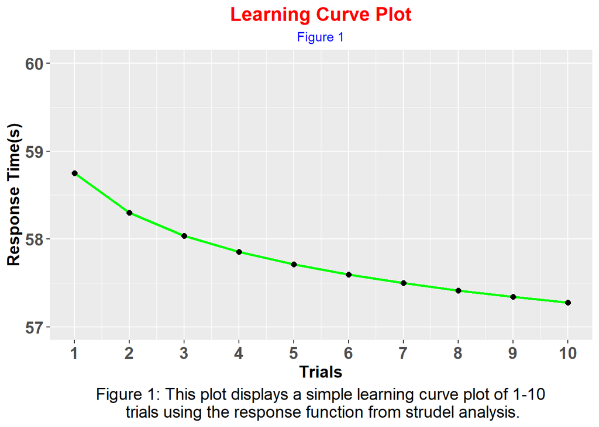

### FIG 2

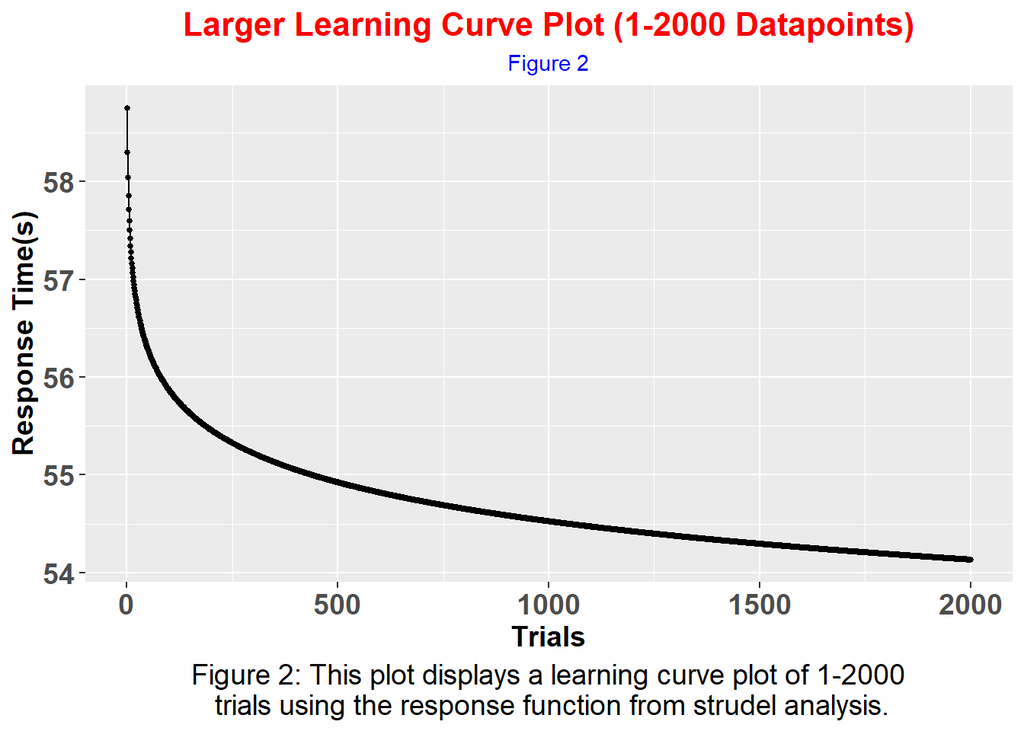

### FIG 3

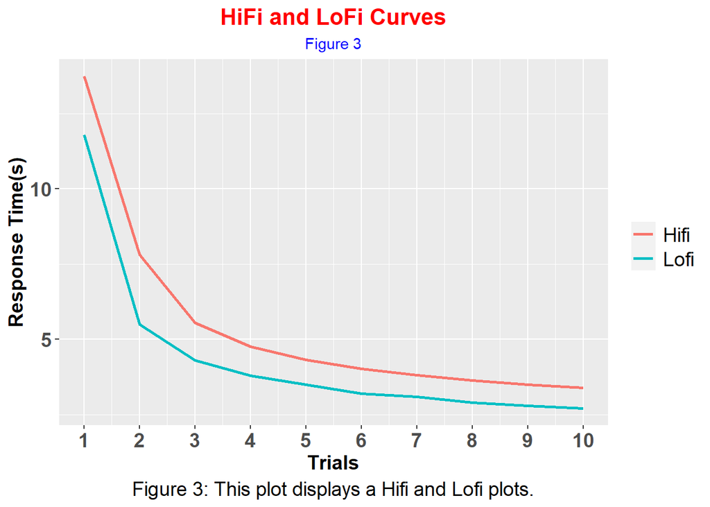

### FIG 4

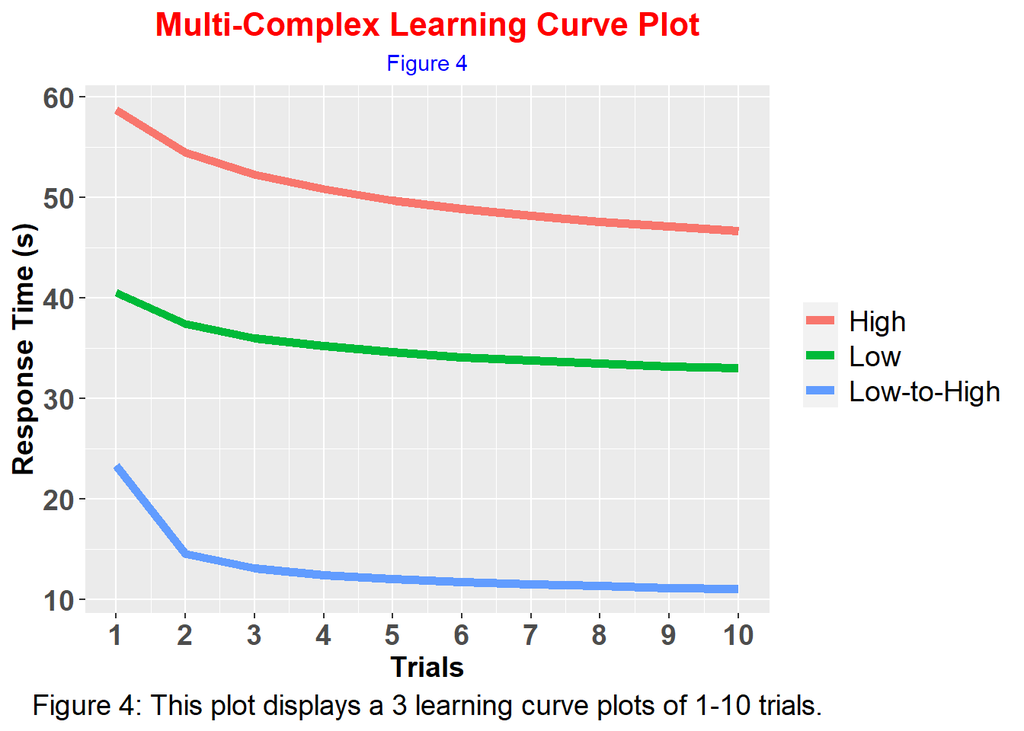

### FIG 5

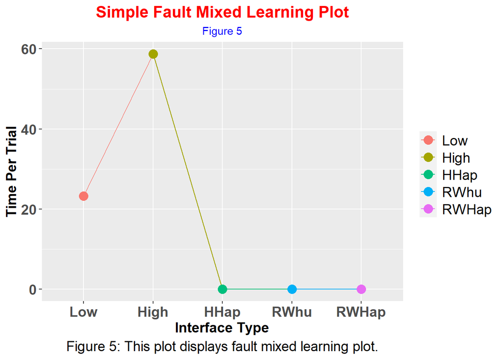

### FIG 6

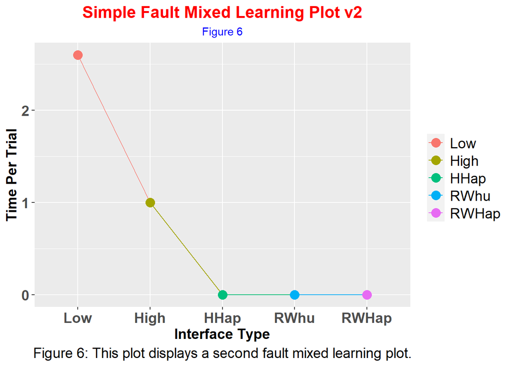

### FIG 7

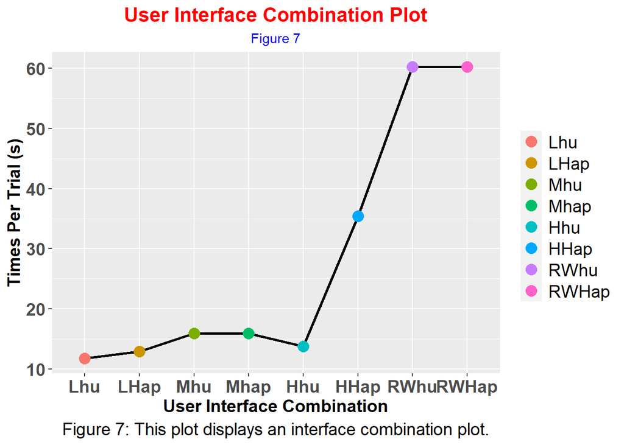

### FIG 8

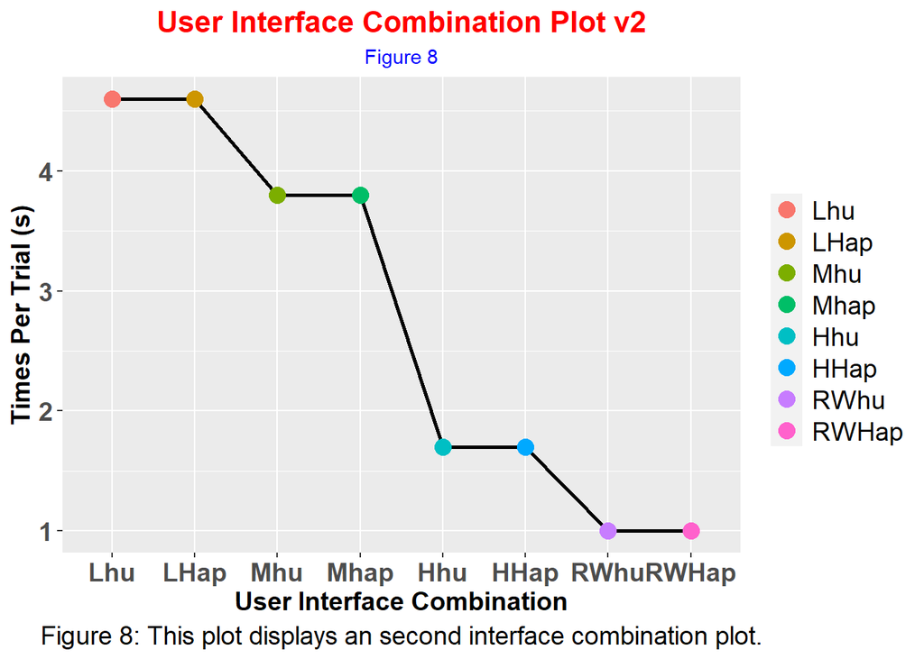

### FIG 9

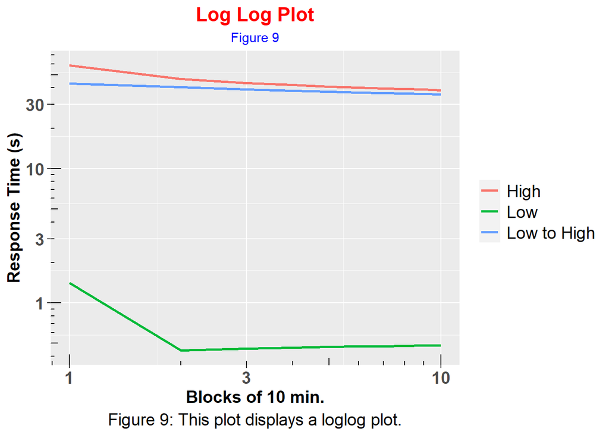

```
##    trials trials_per_min RT total_reps log_base10 low_values delta_Ln
## 1       1            1.0 59         10        1.0         43     1.41
## 2       2            1.3 47         13        1.1         40     0.44
## 3       3            1.4 44         26        1.4         39     0.46
## 4       4            1.4 42         40        1.6         38     0.46
## 5       5            1.5 41         54        1.7         37     0.47
## 6       6            1.5 40         69        1.8         37     0.47
## 7       7            1.5 40         84        1.9         37     0.48
## 8       8            1.5 39         99        2.0         36     0.48
## 9       9            1.5 39        115        2.1         36     0.48
## 10     10            1.6 38        130        2.1         36     0.48
```

### FIG 10

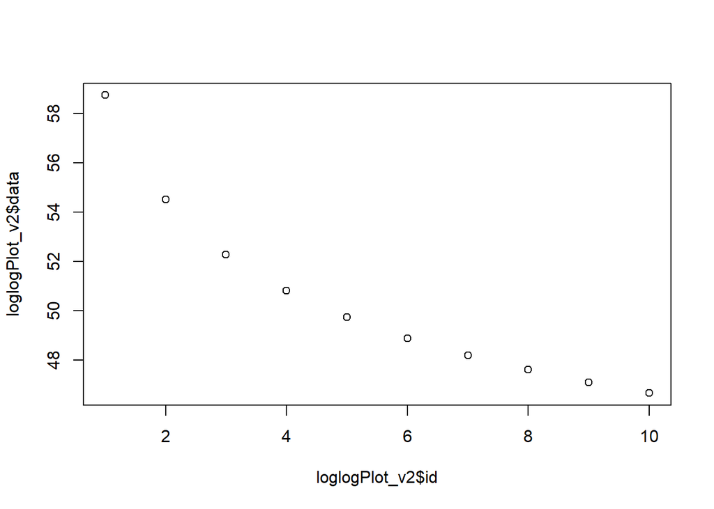

```
##    id trials_per_min data
## 1   1            1.0   59
## 2   2            1.3   55
## 3   3            1.4   52
## 4   4            1.4   51
## 5   5            1.5   50
## 6   6            1.5   49
## 7   7            1.5   48
## 8   8            1.5   48
## 9   9            1.5   47
## 10 10            1.6   47
```

### UPDATES

- **Update 07/28/20**
  - Successfully sorted categorical data with factor function
  - Added more plots & better visualization aspects
- **Update 08/05/20**
  - Added comments
  - Updated variables to be more description
  - Added more plots & better visualization aspects
  - Add default legend name, and key (no documentation found on this that works)
  - Learn to plot Read log/log plot and create complex graph Help function: help(“ggplot”) Change code to reflect
- **Update 08/11/20**
  - ! Need to change plot number system from double to int on x/y axis.
  - ! Unsuccessful with reading alpha input for various value calculations
  - Save plots via code ggplot(), next phase to generate automated reports
  - Corrected x,y axis labels to
  - ! Reading on log log plots, and trying to compute Change legend title to blank
- **Update 08/14/20**
  - Create reports using R markdown
  - Updated errors, bugs, aesthetics
- **Update 08/17/20**
  - Updated x,y axis to be int not float
  - Updated errors, bugs, aesthetics
- **Update 08/25/20**
  - Updated version control
  - Constructed log graph using power law formula
  - Commented plots in code
  - ! Add descriptions to plots, rename plots
  - ! Generate complex plots from strudel analysis
  - ! Add task analysis from strudel into a matrix in R
- **Update 08/27/20**
  - Added labels description to Strudel plots
  - Renamed Strudel plots
  - Changed label visualization
- **Update 09/02/20**
  - Constructed log log plot from strudel analysis
  - Updated plots visualizations
- **Update 09/09/20**
  - ! Make x.y labels bigger
  - ! Use function to generate 1000 trials
  - ! Change high to lo labels and low labels fig 9-11

#### Programming done by [Fredrick Ryans](https://github.com/gremlokk/)

#### Email: *fxr5077@psu.edu*

#### [>> Applied Cognitive Science Lab <<](http://acs.ist.psu.edu/wp/)